# Tree-based modelling

2022-12-23

## Data overview

We use the Spotify dataset obtained via the preprocessing.R script, where is each observation is a track with its attributes (e.g. track name and artists as well as musical traits like energy and key)

As shown below, there are more than 100 genres, with a good number being kids/children.

Our aim is to predict which tracks are children songs, using tree-based modelling.

```r
filtered %>% count(track_genre, sort = TRUE)
```

```
## # A tibble: 105 × 2
##    track_genre        n
##    <chr>          <int>
##  1 heavy-metal      598
##  2 j-idol           571
##  3 honky-tonk       564
##  4 children         553
##  5 kids             466
##  6 detroit-techno   455
##  7 study            421
##  8 new-age          402
##  9 romance          327
## 10 grindcore        323
## # … with 95 more rows
```

Let’s create a new outcome column (True if the track is a children song, false if otherwise) and drop unnecessary columns.

We’ll split the data randomly and by strata into a training and test set to minimize class imbalances.

```r
data <- filtered %>%
  mutate(outcome = case_when(
    track_genre == "children" ~ TRUE,
    track_genre == "kids" ~ TRUE,
    TRUE ~ FALSE
  )) %>%
  select(-track_id, -artists, -track_name, -album_name, -track_genre)

set.seed(1)
data_split <- initial_split(data, prop = 0.9, strata = outcome)
training_data <- training(data_split)
test_data <- testing(data_split)
```

## Decision Tree

### Create and train decision tree

Using a correlation heatmap, we can identify which variables seem to correlate with whether a track is a children song: danceability, valence, and duration_ms.

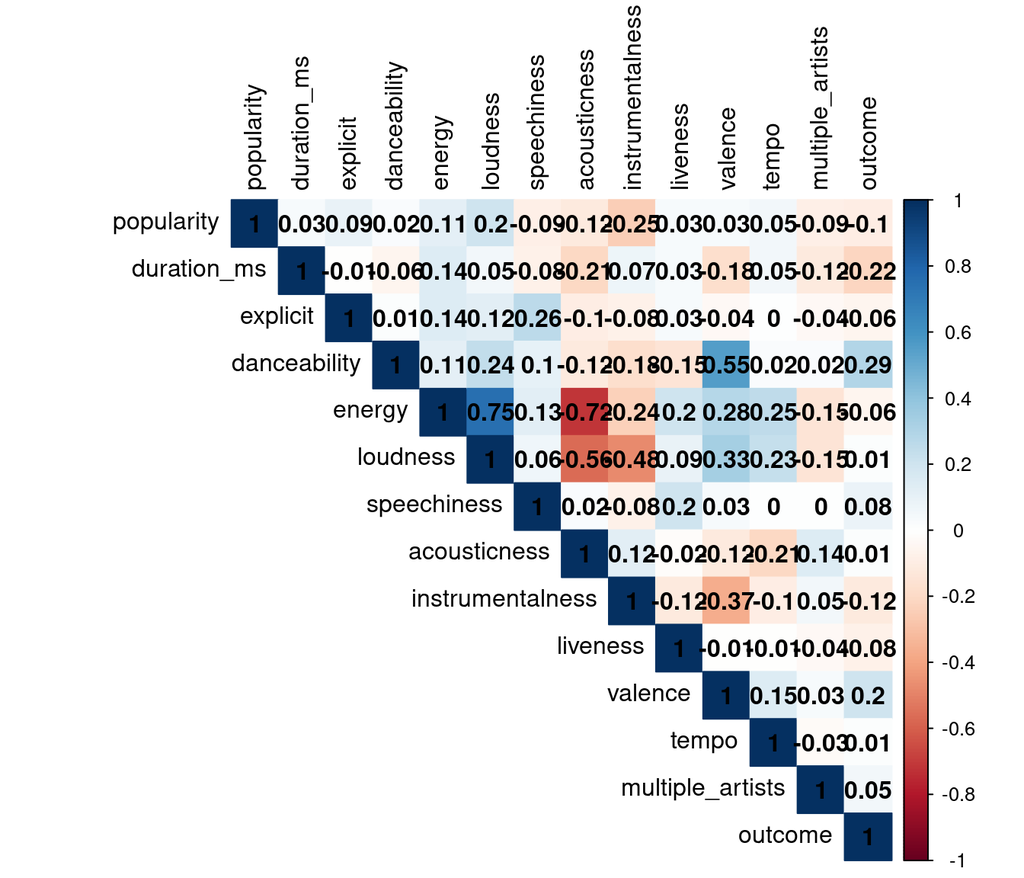

```r
library(corrplot)

training_data %>%
  mutate(explicit = as.numeric(explicit), outcome = as.numeric(outcome), multiple_artists = as.numeric(multiple_artists)) %>%
  select(where(is.numeric)) %>%
  cor(.) %>%
  round(2) %>%
  corrplot(
    method = "color",
    type = "upper",
    addCoef.col = "black",
    tl.col = "black"
  )
```

Now we create a decision tree and use the training data to fit the model. We see that danceability and duration of the track are major nodes in the tree.

```r
training_data$outcome <- as_factor(training_data$outcome)

tree <- decision_tree() %>%
  set_engine("rpart") %>%
  set_mode("classification") %>%
  fit(formula = outcome ~  ., data = training_data)

tree
```

```
## parsnip model object
##
## n= 15237
##
## node), split, n, loss, yval, (yprob)
##       * denotes terminal node
##
##   1) root 15237 913 FALSE (0.94008007 0.05991993)
##     2) danceability< 0.8155 14526 588 FALSE (0.95952086 0.04047914)
##       4) danceability< 0.6655 11449 255 FALSE (0.97772731 0.02227269) *
##       5) danceability>=0.6655 3077 333 FALSE (0.89177771 0.10822229)
##        10) duration_ms>=123122 2834 227 FALSE (0.91990120 0.08009880)
##          20) duration_ms>=236646.5 1097  13 FALSE (0.98814950 0.01185050) *
##          21) duration_ms< 236646.5 1737 214 FALSE (0.87679908 0.12320092)
##            42) popularity>=15.5 1398 107 FALSE (0.92346209 0.07653791) *
##            43) popularity< 15.5 339 107 FALSE (0.68436578 0.31563422)
##              86) instrumentalness>=0.00493 151   9 FALSE (0.94039735 0.05960265) *
##              87) instrumentalness< 0.00493 188  90 TRUE (0.47872340 0.52127660)
##               174) acousticness>=0.5195 59   7 FALSE (0.88135593 0.11864407) *
##               175) acousticness< 0.5195 129  38 TRUE (0.29457364 0.70542636) *
##        11) duration_ms< 123122 243 106 FALSE (0.56378601 0.43621399)
##          22) instrumentalness>=0.453 57   1 FALSE (0.98245614 0.01754386) *
##          23) instrumentalness< 0.453 186  81 TRUE (0.43548387 0.56451613)
##            46) danceability< 0.7635 134  61 FALSE (0.54477612 0.45522388) *
##            47) danceability>=0.7635 52   8 TRUE (0.15384615 0.84615385) *
##     3) danceability>=0.8155 711 325 FALSE (0.54289733 0.45710267)
##       6) duration_ms>=164712 365  70 FALSE (0.80821918 0.19178082)
##        12) instrumentalness>=0.00284 172   4 FALSE (0.97674419 0.02325581) *
##        13) instrumentalness< 0.00284 193  66 FALSE (0.65803109 0.34196891)
##          26) popularity>=19.5 137  25 FALSE (0.81751825 0.18248175) *
##          27) popularity< 19.5 56  15 TRUE (0.26785714 0.73214286) *
##       7) duration_ms< 164712 346  91 TRUE (0.26300578 0.73699422)
##        14) instrumentalness>=0.2005 47   7 FALSE (0.85106383 0.14893617) *
##        15) instrumentalness< 0.2005 299  51 TRUE (0.17056856 0.82943144)
##          30) explicit>=0.5 17   0 FALSE (1.00000000 0.00000000) *
##          31) explicit< 0.5 282  34 TRUE (0.12056738 0.87943262) *
```

### Predict and evaluate model

The model has high accuracy but low recall as the dataset is still imbalanced, with children songs falling in the minority class. In other words, the model is able to make many correct predictions on the basis that most tracks aren’t children songs, but it has less ability to determine children songs correctly.

```r
test_data$outcome <- as_factor(test_data$outcome)

predictions <- predict(tree, new_data = test_data, type = "class") %>%
  mutate(true_class = test_data$outcome)

confusion_matrix <- conf_mat(predictions, estimate = .pred_class, truth = true_class)
confusion_matrix
```

```
##           Truth
## Prediction FALSE TRUE
##      FALSE  1576   55
##      TRUE     12   51
```

## Improving the model

### Oversampling with “SMOTE”

```r
library(smotefamily)
library(patchwork)

data_for_smote <- training_data %>%
  mutate(explicit = as.numeric(explicit))

smote_output <- SMOTE(X = select(data_for_smote, where(is.numeric)),target = data_for_smote$outcome, K = 5, dup_size = 15)

song_smote <- smote_output$data %>% mutate(outcome = as.factor(class)) %>% select(-class)
```

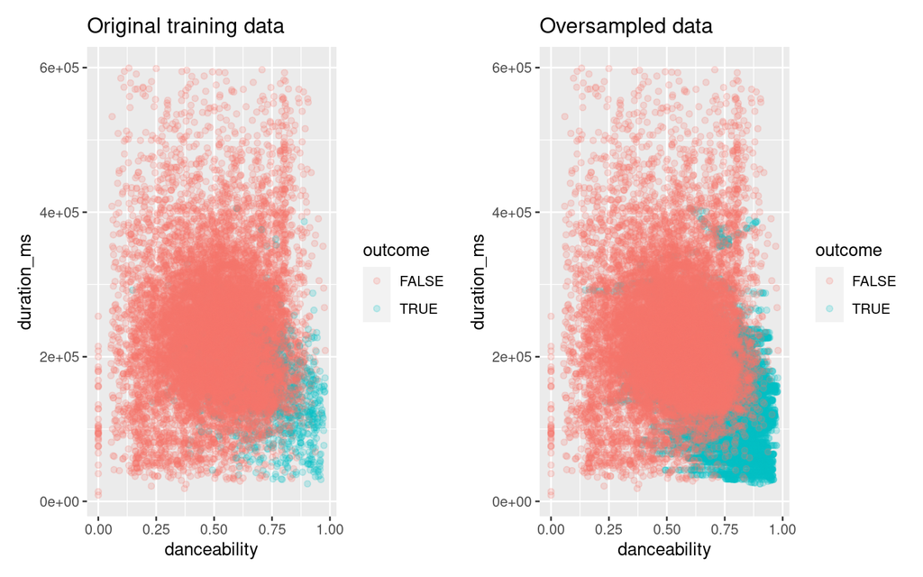

```r
plot1 <- ggplot(training_data, aes(x = danceability, y = duration_ms, color = outcome)) + geom_point(alpha = .2) + ggtitle("Original training data")

plot2 <- ggplot(song_smote, aes(x = danceability, y = duration_ms, color = outcome)) + geom_point(alpha = .2) + ggtitle("Oversampled data")

plot1 + plot2
```

### Build and tune random forest model

Next, we’ll further split the over-sampled training data into train and validation set to train a random forest model.

```r
library(ranger)

set.seed(1)
cv_data <- vfold_cv(song_smote, strata = outcome, v = 5) %>% mutate(train = map(splits, ~training(.x)), validate = map(splits, ~testing(.x)))

# Prepare for tuning cross validation folds by varying mtry
cv_tune <- cv_data  %>% crossing(mtry = c(2,4,8,10,12))

# Build a model for each fold & mtry combination
cv_models_randomforest <- cv_tune %>% mutate(model = map2(.x = train, .y = mtry, ~ranger(formula = outcome ~ ., data = .x, mtry = .y, seed = 1)))
```

We’ll generate predictions on the validation set and evaluate them. The model with 4 mtry has the best performance.

```r
# Generate and evaluate predictions
cv_eval_randomforest <- cv_models_randomforest %>% mutate(
  validate_actual = map(validate, ~.x$outcome == TRUE),
  validate_predicted = map2(.x = model, .y = validate, ~predict(.x, .y, type = "response")$predictions == TRUE)
)

#Calculate recall for each cross-validation fold (measures sensitivity)
recall_vec <- c()
for (i in 1:nrow(cv_eval_randomforest)){
  recall <- sens_vec(as_factor(cv_eval_randomforest$validate_actual[[i]]),as_factor(cv_eval_randomforest$validate_predicted[[i]]))
  recall_vec <- append(recall_vec, recall)
}

# See which mtry yields the best recall
cv_eval_randomforest %>% select(id, mtry) %>% mutate(recall = recall_vec) %>% group_by(mtry) %>% summarise(mean_recall = mean(recall))
```

```
## # A tibble: 5 × 2
##    mtry mean_recall
##   <dbl>       <dbl>
## 1     2       0.950
## 2     4       0.950
## 3     8       0.946
## 4    10       0.944
## 5    12       0.942
```

## Measure test performance with new model

We see a slight boost in overall accuracy, with a slight improvement to recall as well.

```r
best_model <- rand_forest(trees = 500, mtry = 4) %>%
  set_mode("classification") %>%
  set_engine("ranger") %>%
  fit(as_factor(outcome) ~ . , data = training_data, )



new_predictions <- predict(best_model, test_data) %>% bind_cols(test_data)

conf_mat(new_predictions, estimate = .pred_class, truth = outcome)
```

```
##           Truth
## Prediction FALSE TRUE
##      FALSE  1586   51
##      TRUE      2   55
```